# (Flights)

## Bivariate Exploration

### As I found some relationships in the previous part,between unique carrier and delay in arrival or departure, so I will study it in more detail.

### * Let's display arrival delay with unique carrier.

### * We can see digitally in the next figure, where the carrier show the number of delay arrival flights, which arrived on time, and which arrived before their time.

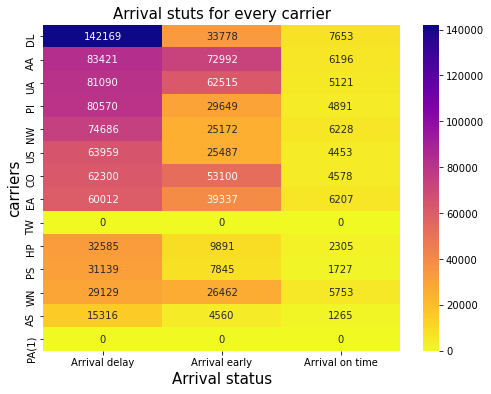

```python
plt.figure(figsize = [8,6])
ad_counts = df.groupby(['ArrDel','UniqueCarrier']).size()
ad_counts = ad_counts.reset_index(name='count')
ad_counts = ad_counts.pivot(index = 'UniqueCarrier', columns = 'ArrDel', values = 'count')
sb.heatmap(ad_counts,annot = True, fmt = 'd',cmap='plasma_r')
plt.title('Arrival stuts for every carrier',size=15)
plt.ylabel('carriers',size=15);
plt.xlabel('Arrival status',size=15);
```

### * This confirms what we have reached from the preliminary analysis, which showed that the flights delays in arrival are concentrated in a few carriers, which are at the top of the list, as we have seen.

### Let's check Departure delay with unique carrier.

### * An indication of the number of flights per carrier at departure.

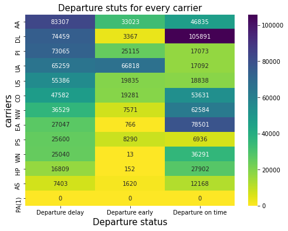

```python
plt.figure(figsize = [8,6])
ad_counts = df.groupby(['DepDel','UniqueCarrier']).size()
ad_counts = ad_counts.reset_index(name='count')
ad_counts = ad_counts.pivot(index = 'UniqueCarrier', columns = 'DepDel', values = 'count')
sb.heatmap(ad_counts,annot = True, fmt = 'd',cmap='viridis_r',)
plt.title('Departure stuts for every carrier',size=15)
plt.ylabel('carriers',size=15)
plt.xlabel('Departure status',size=15);
```

### * Plotting Destinations for every carrier with delayed arrival.

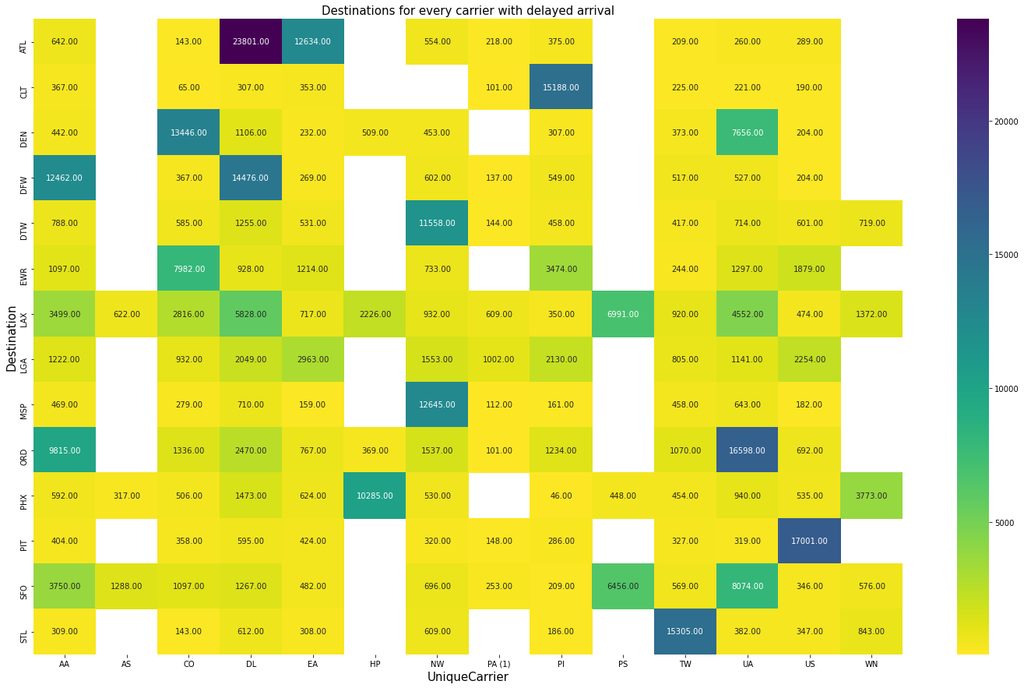

```python
plt.figure(figsize = [25,15])
ad_counts = newarrdelay.groupby(['Dest','UniqueCarrier']).size()
ad_counts = ad_counts.reset_index(name='count')
ad_counts = ad_counts.pivot(index = 'Dest', columns = 'UniqueCarrier', values = 'count')
ad_counts=ad_counts[:30]
sb.heatmap(ad_counts,annot = True, fmt = '.2f',cmap='viridis_r')
plt.title('Destinations for every carrier with delayed arrival',size=15)
plt.ylabel('Destination',size=15)
plt.xlabel('UniqueCarrier',size=15);
```

### * Plotting Destinations for every carrier with delayed departure.

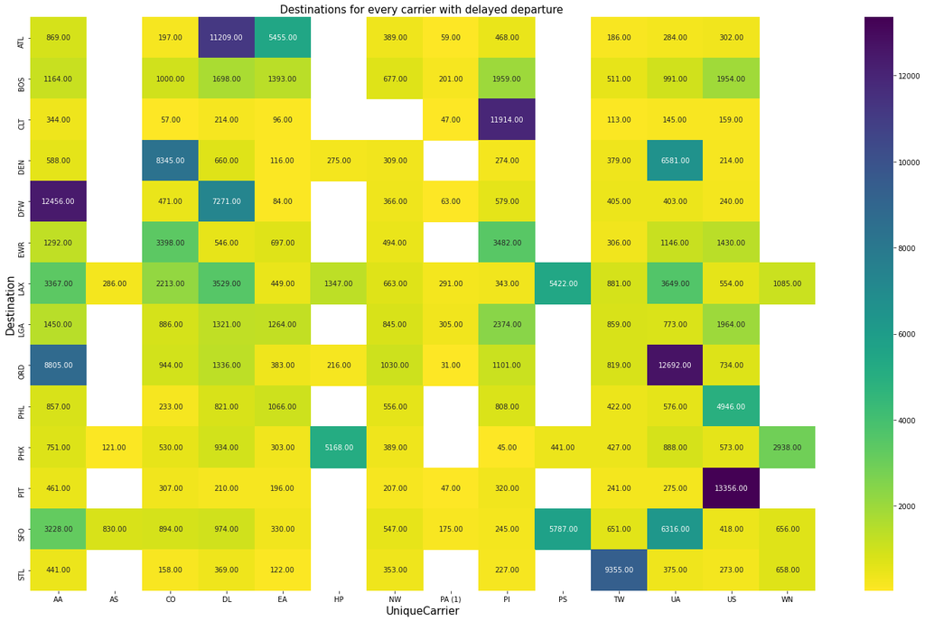

```python
plt.figure(figsize = [25,15])
ad_counts = newdepdelay.groupby(['Dest','UniqueCarrier']).size()
ad_counts = ad_counts.reset_index(name='count')
ad_counts = ad_counts.pivot(index = 'Dest', columns = 'UniqueCarrier', values = 'count')
ad_counts=ad_counts[:30]
sb.heatmap(ad_counts,annot = True, fmt = '.2f',cmap='viridis_r')
plt.title('Destinations for every carrier with delayed departure ',size=15)
plt.ylabel('Destination',size=15)
plt.xlabel('UniqueCarrier',size=15);
```

### * Here I display new plotting which include Frequency of destination for delayed departure flights for each carrier, and it show that, delay is concentrated to certain destinations and carriers as we said before, and that answerring for the question which I added.

### Limitation:

### * Columns which include delay reason are empty so i can't determine kind of delay.

# Conclution:

### * I found that there was a strong relationship between cancellation cases and certain original city, destinations and carriers,also the same strong relationship between dealyed and the there items 'original city, destinations and carriers,that's answering for first question.

### * As weather column empty of data so I can't be sure if weather effect on cancel and delay cases but we know bad weather has strong relation on aviation traffic,in the same time december has the highest count of cancelled and delayed flights and that maybe becouse of weather.

### * There is certain month has the high count of cancelled and delayed flights as we see it's December.